# Scaling Models

2021-09-30

## Methods

In this module you will learn about three popular scaling models, predominantly used by political scientists. Those are:

- Wordscore (Laver, Benoit, and Garry 2003)
- Wordfish (Slapin and Proksch 2008)
- Wordshoal (Lauderdale and Herzog 2016)

Furthermore, we will look at how various degrees of preprocessing influence the scores of these scaling models.

## Data

- The [Manifesto Project](https://manifestoproject.wzb.eu/information/documents/information) analyses parties’ election manifestos in order to study parties’ policy preferences.
- To access the data in the Manifesto Corpus, an account for the Manifesto Project webpage with an API key is required.
- You can create one at https://manifesto-project.wzb.eu/signup. You then can create and download the API key on your profile page.

## Degrees of Preprocessing

No preprocessing

```r
ukm.dfm.1 <- dfm(ukm.c)
ukm.tm.1 <- convert(ukm.dfm.1, to = "tm")
```

Modest preprocessing

```r
ukm.dfm.2 <- dfm(ukm.c, remove_punct = TRUE, remove_numbers = TRUE, stem = TRUE)
ukm.tm.2 <- convert(ukm.dfm.2, to = "tm")
```

Full preprocessing

```r
ukm.dfm.3 <- dfm(ukm.c, remove_punct=TRUE, remove_numbers=TRUE, stem=TRUE, remove=stopwords("english"))
ukm.dfm.3 <- dfm_trim(ukm.dfm.3, min_termfreq = 5, min_doc = 3)
ukm.tm.3 <- convert(ukm.dfm.3, to = "tm")
```

🤓: Vary term and document frequency and investigate its effects!

## Describing differences between the 3 corpora

|  | no | modest | full |
| --- | --- | --- | --- |
| Terms | 14395 | 8748 | 3155 |
| Non-/sparse entries | 64495/223405 | 44776/130184 | 34801/28299 |
| Sparsity | 78% | 74% | 45% |
| Maximal term length | 59 | 59 | 16 |

## Scaling Models

## Latent variable model

\(\theta->W\)

Typically, scaling models assume that

- relative word usage is reflective of political ideology;
- positions are unidimensional in \(W\);
- positions drive word counts stochastically according to a particular form for \(P(W_j|\theta)\);
- bag of words: counts of \(W_j\) are conditionally independent given \(\theta\)

\[ P(W_1...W_v) = \prod_{j}^{V}P(W_j|\theta)P(\theta) \]

## Wordscore Model

Wordscores is a (supervised) scaling model for estimating the positions for dimensions that are specified a priori (Laver, Benoit, and Garry 2003).

- Each word \(j\) has a policy position (word score) \(\pi_j\).
- A reference document needs to be specified.
- Document positions are averaged over its words’ positions.

### Example

- Two texts (\(A\), \(B\))
- The word “summer” is used 10 times per 1000 words in text \(A\) and 30 times per 1000 words in text \(B\).
- Conditional on observing the word “summer,” we read text \(A\) with probability 0.25 and text B with probability 0.75.
- Once we assign reference values to the reference texts, we can compute a “word score.”
- Suppose reference text A has position \(-1\), and text B position \(+1\), the score of word “summer” is: \(0.25(−1.0) + 0.75(1.0) = −0.25 + 0.75 = 0.5\)

#### Laver, Benoit, and Garry (2003)

The expert Wordscore survey estimates for 1992 can be found in Laver, Benoit, and Garry (2003), p.320: The score for Liberal Democrats is \(8.21\), the Labour Party scores \(5.35\) and the Conservatives yield a score of \(17.21\).

### Run the Wordscore Model

`textmodel_wordscores()` implements Laver, Benoit, and Garry (2003) Wordscores method.

```r
ws.3 <- textmodel_wordscores(ukm.dfm.3,refsc)
ws.pr.3 <- predict(ws.3, rescaling = "lbg")
names(ws.pr.3)<-gsub("\\..*","",ukm$doc_id)
```

### Plotting the Document Positions

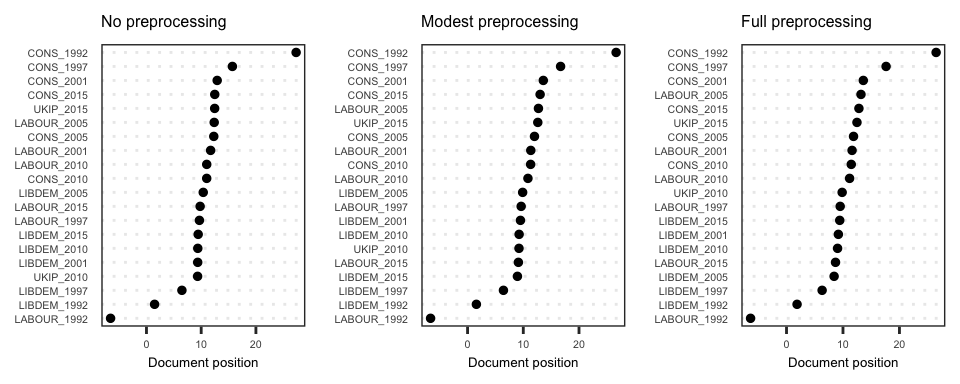

### Descriptive Statistics

The table shows that the three different corpi do not vary much concerning descriptive statistics of their Wordscores.

|  | no | modest | full |
| --- | --- | --- | --- |
| mean | 10.41 | 10.39 | 10.41 |
| sd | 6.19 | 6.19 | 6.19 |
| min | -6.56 | -6.64 | -6.37 |
| max | 27.35 | 26.66 | 26.49 |

### Wordscores of Economic Terms

We investigate the following 10 economic terms: “return,” “trade,” “cost,” “utility,” “market,” “firm,” “expense,” “income,” “cash,” and “tariff.”

🤓: Think about terms that you’re interested in and extract their wordscores.

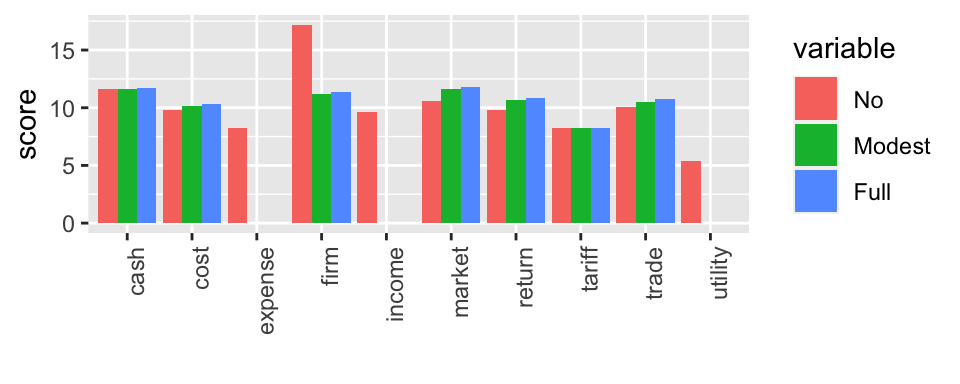

## Wordfish Model

### Theory

Slapin and Proksch (2008)

- Unsupervised scaling
- No reference texts
- Similar to item response models (e.g. NOMINATE for roll call voting).
- The position word relationship is:

\(W_{ij} ∼ Poisson(\mu_{ij})\)

\(log(\mu_{ij}) = \psi_j +\beta_j \theta_i + \alpha_i\)

- Each word is a Poisson Process (stochastic component) driven by word and document parameters (the systematic component)
- Word parameters:
  - \(\beta\) how fast counts increase or decrease with changes in position
  - \(\psi\) how frequent words are irrespective of position

### Estimation

Wordfish models are fit using Conditional Maximum Likelihood (regression without independent variables).

Iterate:

- Fix document parameters (\(\alpha\) and \(\theta\)) and maximize word parameters (\(\beta\) and \(\psi\))
- Fix new word parameters (\(\beta\) and \(\psi\)) and maximize document parameters (\(\alpha\) and \(\theta\))
- This can be quite slow depending on the size of your dataset

### Run Wordfish Model

- Before running the Wordfish model, we specify the direction of the scale.
- We define the `UKIP_2015` as the most right position whereas `LIBDEM_1992` is defined as the most left position.

```r
wf.1 <- textmodel_wordfish(ukm.dfm.1,dir=c(13,20))
```

### Compare Wordfish Scores

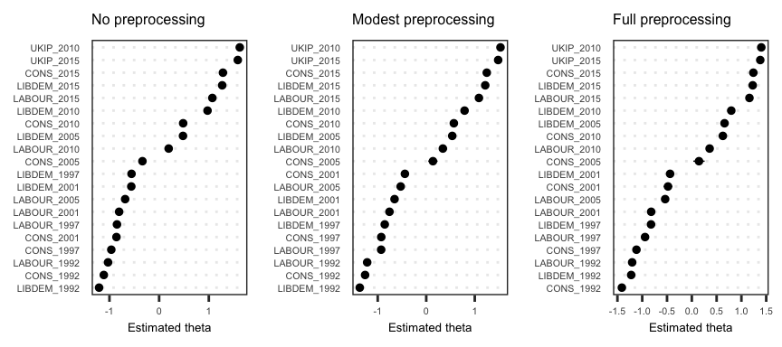

## Compare Wordfish to Wordscore

The variation of the wordfish-scores is more dependent on the degree of preprocessing than the wordscore values are. A distinct pattern of the wordscore plot is that the reference values appear as distinct rises or drops. Such a pattern is no longer observed in the wordfish graph because this model does not use reference texts. However, instead of spiking at reference values, the fully preprocessed wordfish model spikes at very recent texts, independent of the political direction. Such a distinctive time trend is not present in the wordscore model.

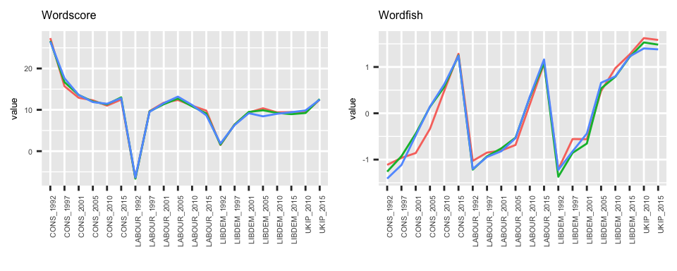

## Compare Wordfish to Wordscore

The graphs below show that the wordfish model only performs well in ordering the parties on a political spectrum for recent texts (documents from the year 2015). The ordering of older texts seems to be arbitrary. The wordscore model on the contrary correctly assigns texts as right or left wing independent of the year.

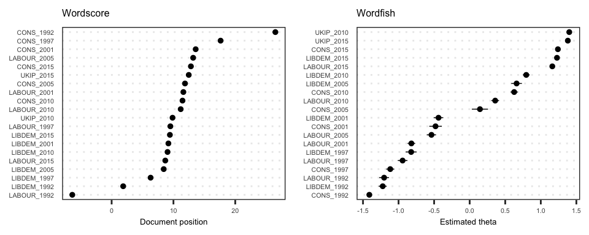

## Wordshoal

- An extension of Wordfish specifically for legislative debates.
- Goal: estimate legislator positions.
- Step 1: debate-level scaling model: Wordfish. These are debate specific estimates that are not comparable.
- Step 2: treat estimates as data and use factor analysis to aggregate them into one or more general latent positions for each legislator.

## Critique

Bruinsma and Gemenis (2019) criticize the wordscore model

- scale the Euromanifestos of 117 political parties across 23 countries on 4 salient dimensions of political conflict
- assess validity
  - by comparing the Wordscores estimates to expert surveys and other judgmental measures,
  - by examining the Wordscores’s estimates ability to predict party membership in the European Parliament groups.
- find that the Wordscores estimates correlate poorly with expert and judgmental measures of party positions
- conclude that Wordscores does not live up to its original claim of a “quick and easy” language blind method

## It’s your turn! 👩‍💻 ~12’

## References

Bruinsma, Bastiaan, and Kostas Gemenis. 2019. “ Validating Wordscores: The Promises and Pitfalls of Computational Text Scaling.” *Communication Methods and Measures* 13 (3): 212–27. https://doi.org/10.1080/19312458.2019.1594741.

Lauderdale, Benjamin E, and Alexander Herzog. 2016. “ Measuring Political Positions from Legislative Speech.” *Political Analysis* 24 (3): 374–94. https://doi.org/10.1093/pan/mpw017.

Laver, Michael, Kenneth Benoit, and John Garry. 2003. “ Extracting policy positions from political texts using words as data.” *American Political Science Review* 97 (2): 311–31.

Slapin, Jonathan B., and Sven Oliver Proksch. 2008. “ A scaling model for estimating time-series party positions from Texts.” *American Journal of Political Science* 52 (3): 705–22. https://doi.org/10.1111/j.1540-5907.2008.00338.x.